# Proteomic Data Analysis and Visualization

Alex Sanchez

October 22, 2022

# Introduction

## Disclaimer

*This is a toy example based on a dataset and some questions posed by one course attendant. While the process is similar to what one would do in a real case it has been simplified to make it easier to follow, so that the final results of the analysis should not be taken as definitive*

## The problem

- The experiment has analyzed (3 + 3) PDX models of two different subtypes using Phosphopeptide enriched samples.
- LC-MS analysis of 2 technical duplicates has been performed on each sample.
- The results set consisted of *Normalized abundances of MS signals for ca. 1400 phosphopeptides*
- Goal of the analysis: **search phosphopeptides that allow differentiation of the two tumor groups*
- This should be made with both Statistical Analysis and visualization.
- Data have been provided as an excel file: `TIO2+PTYR-human-MSS+MSIvsPD.XLSX`
- Groups are defined as:
  - MSS group: Samples M1, M5 and T49,
  - PD group: Samples M42, M43 and M64 with two technical replicates for each sample
- The first column, “SequenceModification”" contains abundance values for the distinct phosphopetides. Other columns can be omitted.

# Data exploration

## Reading data

Start reading data. Remember spreadsheets from the same workbook can be read separately.

*Don’t forget to select “`Session / Set working Directory / to Source File Location`” before you start with the analysis*.

```r
require(readxl)
phData <- read_excel(path= "TIO2+PTYR-human-MSS+MSIvsPD.XLSX", sheet=1)
head(phData)
```

| SequenceModifications | Accession | Description | Score | M1_1_MSS | M1_2_MSS | M5_1_MSS | M5_2_MSS | T49_1_MSS | T49_2_MSS | M42_1_PD | M42_2_PD | M43_1_PD | M43_2_PD | M64_1_PD | M64_2_PD | CLASS | PHOSPHO |
| --- | --- | --- | --- | --- | --- | --- | --- | --- | --- | --- | --- | --- | --- | --- | --- | --- | --- |
| LYPELSQYMGLSLNEEEIR[2] Phospho\|[9] Oxidation | O00560 | Syntenin-1 OS=Homo sapiens GN=SDCBP PE=1 SV=1 | 48.07 | 24.29438 | 44475.964 | 0.000 | 6269.141 | 1135.8169 | 21933.90 | 0.000 | 0.00 | 772.9056 | 2136.746 | 1820.724 | 1727.9098 | H | Y |
| VDKVIQAQTAFSANPANPAILSEASAPIPHDGNLYPR[35] Phospho | O00560 | Syntenin-1 OS=Homo sapiens GN=SDCBP PE=1 SV=1 | 67.05 | 0.00000 | 43138.904 | 2102.056 | 50355.051 | 248.9275 | 3239.16 | 1315.904 | 0.00 | 0.0000 | 0.000 | 0.000 | 892.3565 | H | Y |
| VIQAQTAFSANPANPAILSEASAPIPHDGNLYPR[32] Phospho | O00560 | Syntenin-1 OS=Homo sapiens GN=SDCBP PE=1 SV=1 | 77.71 | 3412.60332 | 172143.040 | 77323.019 | 307637.429 | 98442.2773 | 192982.37 | 24851.344 | 16547.95 | 5565.2821 | 0.000 | 3264.563 | 5901.9577 | H | Y |
| HADAEMTGYVVTR[6] Oxidation\|[9] Phospho | O15264 | Mitogen-activated protein kinase 13 OS=Homo sapiens GN=MAPK13 PE=1 SV=1 | 44.87 | 220431.17880 | 145656.887 | 104287.815 | 75887.365 | 773377.4981 | 481165.54 | 1027196.292 | 1163747.38 | 4080239.1820 | 4885818.113 | 3093786.793 | 2759104.5440 | H | Y |
| HADAEMTGYVVTR[9] Phospho | O15264 | Mitogen-activated protein kinase 13 OS=Homo sapiens GN=MAPK13 PE=1 SV=1 | 67.42 | 18254.77813 | 8529.755 | 35955.901 | 44102.316 | 57145.1682 | 34638.01 | 21231.256 | 49499.70 | 666107.0448 | 379313.615 | 255792.117 | 579765.0018 | H | Y |
| STGPGASLGTGYDR[12] Phospho | O15551 | Claudin-3 OS=Homo sapiens GN=CLDN3 PE=1 SV=1 | 63.69 | 644513.31840 | 261938.025 | 187023.484 | 124867.715 | 4487443.6920 | 2572575.27 | 535809.187 | 434645.89 | 91361.8781 | 65997.913 | 243250.439 | 206632.6444 | H | Y |

```r
targets <- read_excel(path= "TIO2+PTYR-human-MSS+MSIvsPD.XLSX", sheet=2)
show(targets)
```

```
## # A tibble: 12 x 4
##    Sample...1 Sample...2 Individual Phenotype
##    <chr>      <chr>           <dbl> <chr>
##  1 M1_1       M1                  1 MSS
##  2 M1_2       M1                  1 MSS
##  3 M5_1       M5                  2 MSS
##  4 M5_2       M5                  2 MSS
##  5 T49_1      T49                 3 MSS
##  6 T49_2      T49                 3 MSS
##  7 M42_1      M42                 4 PD
##  8 M42_2      M42                 4 PD
##  9 M43_1      M43                 5 PD
## 10 M43_2      M43                 5 PD
## 11 M64_1      M64                 6 PD
## 12 M64_2      M64                 6 PD
```

## Data visualization

A first look at file shows there are both numerical and character data. For ease of use we separate numerical values into a data matrix.

```r
library(tidyverse)
abundances <- phData %>% select (5:16)
head(abundances)
```

| M1_1_MSS | M1_2_MSS | M5_1_MSS | M5_2_MSS | T49_1_MSS | T49_2_MSS | M42_1_PD | M42_2_PD | M43_1_PD | M43_2_PD | M64_1_PD | M64_2_PD |
| --- | --- | --- | --- | --- | --- | --- | --- | --- | --- | --- | --- |
| 24.29438 | 44475.964 | 0.000 | 6269.141 | 1135.8169 | 21933.90 | 0.000 | 0.00 | 772.9056 | 2136.746 | 1820.724 | 1727.9098 |
| 0.00000 | 43138.904 | 2102.056 | 50355.051 | 248.9275 | 3239.16 | 1315.904 | 0.00 | 0.0000 | 0.000 | 0.000 | 892.3565 |
| 3412.60332 | 172143.040 | 77323.019 | 307637.429 | 98442.2773 | 192982.37 | 24851.344 | 16547.95 | 5565.2821 | 0.000 | 3264.563 | 5901.9577 |
| 220431.17880 | 145656.887 | 104287.815 | 75887.365 | 773377.4981 | 481165.54 | 1027196.292 | 1163747.38 | 4080239.1820 | 4885818.113 | 3093786.793 | 2759104.5440 |
| 18254.77813 | 8529.755 | 35955.901 | 44102.316 | 57145.1682 | 34638.01 | 21231.256 | 49499.70 | 666107.0448 | 379313.615 | 255792.117 | 579765.0018 |
| 644513.31840 | 261938.025 | 187023.484 | 124867.715 | 4487443.6920 | 2572575.27 | 535809.187 | 434645.89 | 91361.8781 | 65997.913 | 243250.439 | 206632.6444 |

Usually it is convenient that rows can be identified by short-but-meaningful names. One may want to use column “accession” for this goal, but it happens not be usable because there are duplicates in this column and *rownames cannot have duplicates in R*.

This can be solved by creating new names with the `make.names` function.

```r
newRownames <- make.names(phData$Accession, unique=TRUE)
abundances <- as.data.frame(abundances)
rownames(abundances) <- newRownames
head(abundances)
```

|  | M1_1_MSS | M1_2_MSS | M5_1_MSS | M5_2_MSS | T49_1_MSS | T49_2_MSS | M42_1_PD | M42_2_PD | M43_1_PD | M43_2_PD | M64_1_PD | M64_2_PD |
| --- | --- | --- | --- | --- | --- | --- | --- | --- | --- | --- | --- | --- |
| O00560 | 24.29438 | 44475.964 | 0.000 | 6269.141 | 1135.8169 | 21933.90 | 0.000 | 0.00 | 772.9056 | 2136.746 | 1820.724 | 1727.9098 |
| O00560.1 | 0.00000 | 43138.904 | 2102.056 | 50355.051 | 248.9275 | 3239.16 | 1315.904 | 0.00 | 0.0000 | 0.000 | 0.000 | 892.3565 |
| O00560.2 | 3412.60332 | 172143.040 | 77323.019 | 307637.429 | 98442.2773 | 192982.37 | 24851.344 | 16547.95 | 5565.2821 | 0.000 | 3264.563 | 5901.9577 |
| O15264 | 220431.17880 | 145656.887 | 104287.815 | 75887.365 | 773377.4981 | 481165.54 | 1027196.292 | 1163747.38 | 4080239.1820 | 4885818.113 | 3093786.793 | 2759104.5440 |
| O15264.1 | 18254.77813 | 8529.755 | 35955.901 | 44102.316 | 57145.1682 | 34638.01 | 21231.256 | 49499.70 | 666107.0448 | 379313.615 | 255792.117 | 579765.0018 |
| O15551 | 644513.31840 | 261938.025 | 187023.484 | 124867.715 | 4487443.6920 | 2572575.27 | 535809.187 | 434645.89 | 91361.8781 | 65997.913 | 243250.439 | 206632.6444 |

## Plotting data

It is clear that abundance vary in a wide numeric range:

```r
summary(abundances)
```

```
##     M1_1_MSS           M1_2_MSS           M5_1_MSS           M5_2_MSS          T49_1_MSS
##  Min.   :       0   Min.   :       0   Min.   :       0   Min.   :       0   Min.   :       0
##  1st Qu.:    5653   1st Qu.:    5497   1st Qu.:    2573   1st Qu.:    3273   1st Qu.:    9306
##  Median :   30682   Median :   26980   Median :   20801   Median :   26241   Median :   55641
##  Mean   :  229841   Mean   :  253151   Mean   :  232967   Mean   :  261067   Mean   :  542449
##  3rd Qu.:  117373   3rd Qu.:  113004   3rd Qu.:  113958   3rd Qu.:  130132   3rd Qu.:  223103
##  Max.   :16719906   Max.   :43928481   Max.   :15135169   Max.   :19631820   Max.   :49218872
##    T49_2_MSS           M42_1_PD           M42_2_PD           M43_1_PD           M43_2_PD
##  Min.   :       0   Min.   :       0   Min.   :       0   Min.   :       0   Min.   :       0
##  1st Qu.:    8611   1st Qu.:    5341   1st Qu.:    4216   1st Qu.:   19641   1st Qu.:   17299
##  Median :   46110   Median :   36854   Median :   30533   Median :   67945   Median :   59607
##  Mean   :  462616   Mean   :  388424   Mean   :  333587   Mean   :  349020   Mean   :  358822
##  3rd Qu.:  189141   3rd Qu.:  180252   3rd Qu.:  152088   3rd Qu.:  205471   3rd Qu.:  201924
##  Max.   :29240206   Max.   :48177680   Max.   :42558111   Max.   :35049402   Max.   :63082982
##     M64_1_PD           M64_2_PD
##  Min.   :       0   Min.   :       0
##  1st Qu.:   11038   1st Qu.:    8660
##  Median :   52249   Median :   47330
##  Mean   :  470655   Mean   :  484712
##  3rd Qu.:  209896   3rd Qu.:  206036
##  Max.   :71750330   Max.   :88912734
```

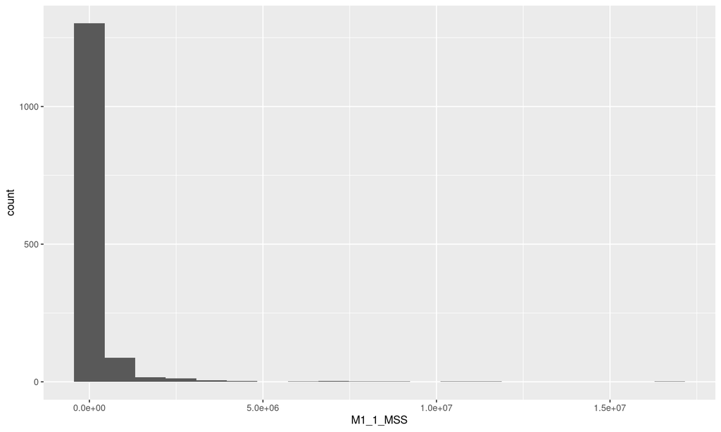

```r
library(ggplot2)
ggplot(abundances)+geom_histogram(aes(x=M1_1_MSS),bins=20)
```

This is better seen with a multiple boxplot, that is one boxplot per column.

### Boxplots in “base R”

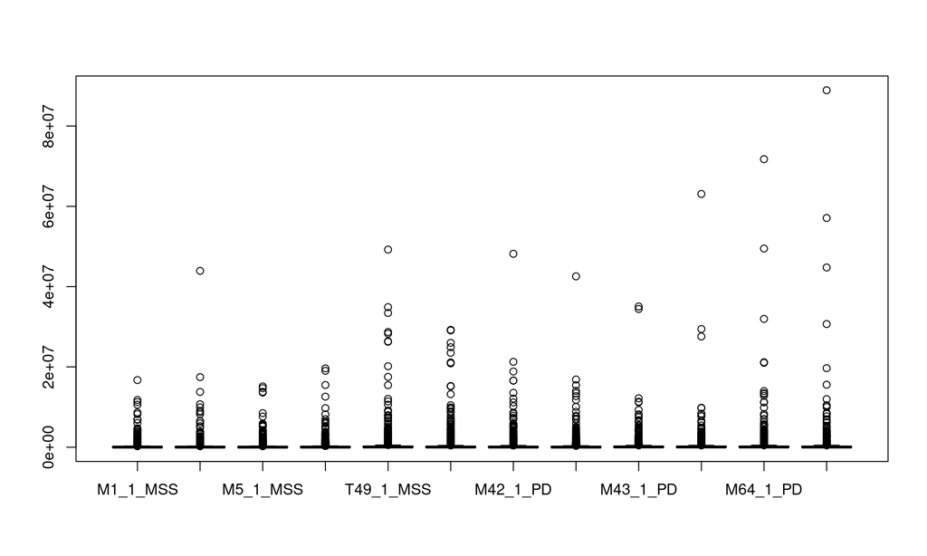

```r
boxplot(abundances)
```

The plot suggests that it may be useful to transform the data taking logarithms. A quick-and-dirty approach is to take logarithms of the data to which we have added 1 to avoid problems with zeroes.

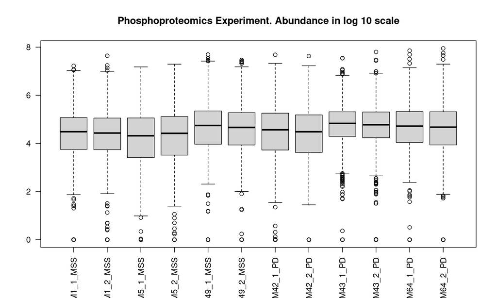

```r
boxplot(log10(abundances+1), las=2, main="Phosphoproteomics Experiment. Abundance in log 10 scale")
```

### Boxplots in `ggplot2`

In ggplot2 a boxplot is seen as a plot that relates one continuous and one categorical variable, so that data has to be reshaped into this type of structure (at least one numerical variable and one or more categorical variables) before the plot can be drawn.

This can easily be done with `dplyr`’s `gather` function.

```r
logDat <- abundances %>%
  gather() %>%
  mutate (logvalues= log (value+1)) %>%
  select (logvalues, key)
head(logDat)
```

|  | logvalues | key |
| --- | --- | --- |
| 1 | 3.230582 | M1_1_MSS |
| 2 | 0.000000 | M1_1_MSS |
| 3 | 8.135524 | M1_1_MSS |
| 4 | 12.303345 | M1_1_MSS |
| 5 | 9.812237 | M1_1_MSS |
| 6 | 13.376252 | M1_1_MSS |

Once we have the data in the required structure we can plot it.

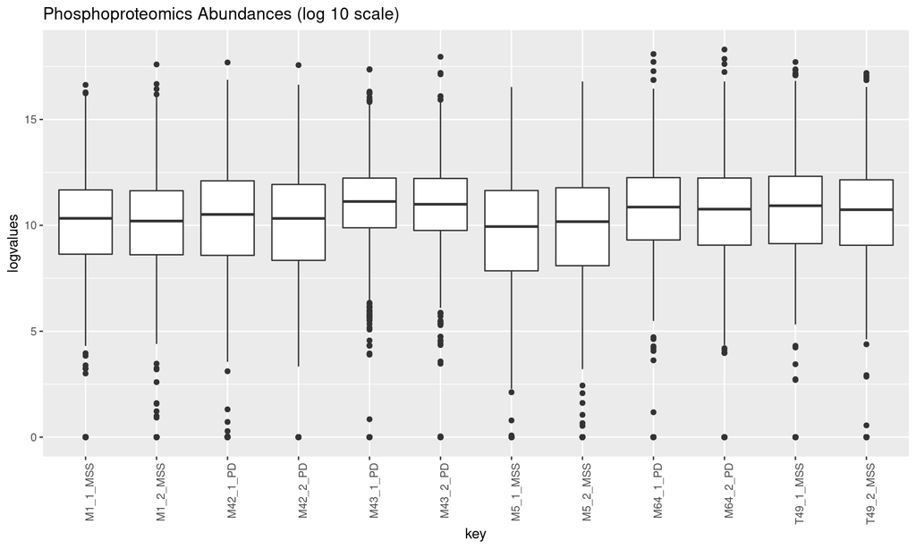

```r
library(ggplot2)
ggplot(logDat) +
  geom_boxplot(aes(x = key, y = logvalues))+
  theme(axis.text.x = element_text(angle = 90, hjust = 1))+
  ggtitle("Phosphoproteomics Abundances (log 10 scale)")
```

Notice that the boxplots are drawn *based on the alphabetic ordering of the categorical variable* and this may not be how we expected to see them!

This can be changed in different ways. Either using a characteristic of the groups to define the order (e.g. order by group median) or simply creating a new factor variable where the desired ordering is imposed.

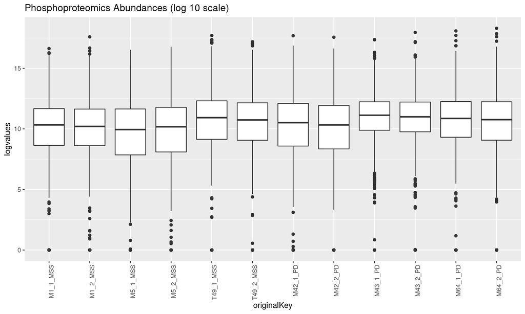

```r
originalKey <- factor(logDat$key, levels=colnames(abundances))
ggplot(logDat) +
  geom_boxplot(aes(x = originalKey, y = logvalues))+
  theme(axis.text.x = element_text(angle = 90, hjust = 1))+
  ggtitle("Phosphoproteomics Abundances (log 10 scale)")
```

### Creating covariates from the labels

In order to use the information on groups (“covariates”) we must extract it from the column names. (**Notice that they have been prepared specifically to contain this information!!!**)

```r
library(stringr)
covs <- str_split(logDat$key, "_", simplify=TRUE)
colnames(covs)<- c("Sample", "Replicate", "Group")
logDat2 <- cbind(logDat,covs)
```

This can be used for showing the groups in the plots

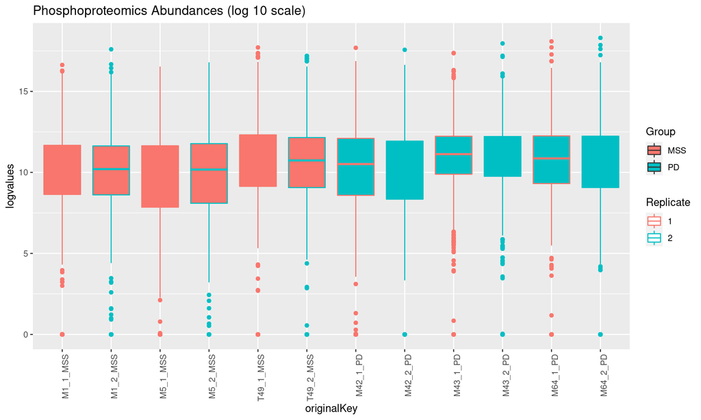

```r
ggplot(logDat2) +
  geom_boxplot(aes(x = originalKey, y = logvalues, fill=Group, colour=Replicate))+
  theme(axis.text.x = element_text(angle = 90, hjust = 1))+
  ggtitle("Phosphoproteomics Abundances (log 10 scale)")
```

## Multivariate visualization: Principal components analysis

A nice way to plot a dataset is to do a Principal Components Analysis and then plot the first components.

For simplicity we use a function that has already been prepared and encapsulated do draw a scatterplot from the results of a PCA. It is available from github.

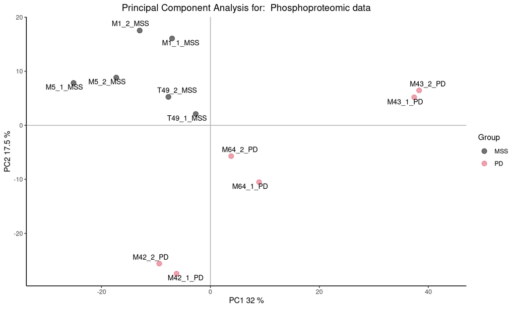

```r
source("https://raw.githubusercontent.com/uebvhir/UEB_PCA/master/UEB_plotPCA3.R")
plotPCA3(datos=as.matrix(log10(abundances+1)), labels=colnames(abundances),
         factor=targets$Phenotype,title ="Phosphoproteomic data",
         scale=FALSE, colores=1:2, size = 3.5, glineas = 2.5)
```

The plot suggests that MSS and PD groups are differnt but the PD group seems more heterogeneous than the MSS one.

# Statistical Analysis

The analysis to select differentially abundant proteins will be based on a package called `limma` used mainly in microarrays. This package is part of Bioconductor (http://bioconductor.org) a giantic project created to develop open source software for omics data analysis based on R.

Packages from Bioconductor need to be installed with a specific function.

```r
if (!(require(limma))){
  source("http://bioconductor.org/biocLite.R")
  biocLite("limma")
}
```

Limma provides a sophisticated approach to omics data analysis based on the theory of the linear model. For simplicity we only describe the main ideas of the approach. Much more information is available in the user’s guide.

The limma approach consists of creating

1. a “design matrix” that describes assignment of samples to groups.
2. a “contrast” matrix that describes the comparisons to be performed

These two matrices are used in a set of calls to provide a list of potentially differentially expressed features.

```r
library(limma)
targets <- as.data.frame(targets)
groups <- as.factor(targets$Phenotype)
designMat <- model.matrix(~ -1 + groups)
show(designMat)
```

```
##    groupsMSS groupsPD
## 1          1        0
## 2          1        0
## 3          1        0
## 4          1        0
## 5          1        0
## 6          1        0
## 7          0        1
## 8          0        1
## 9          0        1
## 10         0        1
## 11         0        1
## 12         0        1
## attr(,"assign")
## [1] 1 1
## attr(,"contrasts")
## attr(,"contrasts")$groups
## [1] "contr.treatment"
```

Technical replicates can be handled using a function called `duplicatecorrelation`that computes the mean correlation between replicates. This correlation is used then in the model fitting process.

```r
if (!require(statmod)) install.packages("statmod")
dupcor <- duplicateCorrelation(abundances, designMat,block=targets$Individual)
dupcor$consensus.correlation
```

```
## [1] 0.8770936
```

Finally a “contrasta matrix” is prepared to describe the comparisons

```r
require(limma)
contMat <- makeContrasts(mainEff=groupsPD-groupsMSS, levels=designMat)
show(contMat)
```

```
##            Contrasts
## Levels      mainEff
##   groupsMSS      -1
##   groupsPD        1
```

Once the design and the contrast matrix are built we proceed as follows:

```r
fit <- lmFit(abundances, designMat, block=targets$Individual,correlation=dupcor$consensus)
fit2 <- contrasts.fit(fit, contMat)
fit2 <- eBayes(fit2)
results<- topTableF(fit2, adjust="BH",  number=nrow(abundances))
head(results)
```

|  | mainEff | AveExpr | F | P.Value | adj.P.Val |
| --- | --- | --- | --- | --- | --- |
| O00193.1 | 802048.92 | 641359.81 | 34.87586 | 0.0001157082 | 0.1663884 |
| P35269.1 | -435826.87 | 412752.57 | 23.39308 | 0.0005694049 | 0.2040053 |
| P16144.3 | 313748.10 | 270927.30 | 22.75343 | 0.0006322067 | 0.2040053 |
| Q5T0Z8.1 | 225849.08 | 176503.85 | 21.01902 | 0.0008488023 | 0.2040053 |
| Q9H1C7 | 677600.13 | 446716.73 | 20.98220 | 0.0008542838 | 0.2040053 |
| P84103 | 27775.59 | 18777.87 | 20.70335 | 0.0008971889 | 0.2040053 |

The results of the analysis is a table where features, here proteins, are ordered from most to least differentially expressed according the results of the comparison performed.

The results can be shown in a *volcano Plot* that plots the biological (fold change) vs statistical (-log (p-value)) effect.

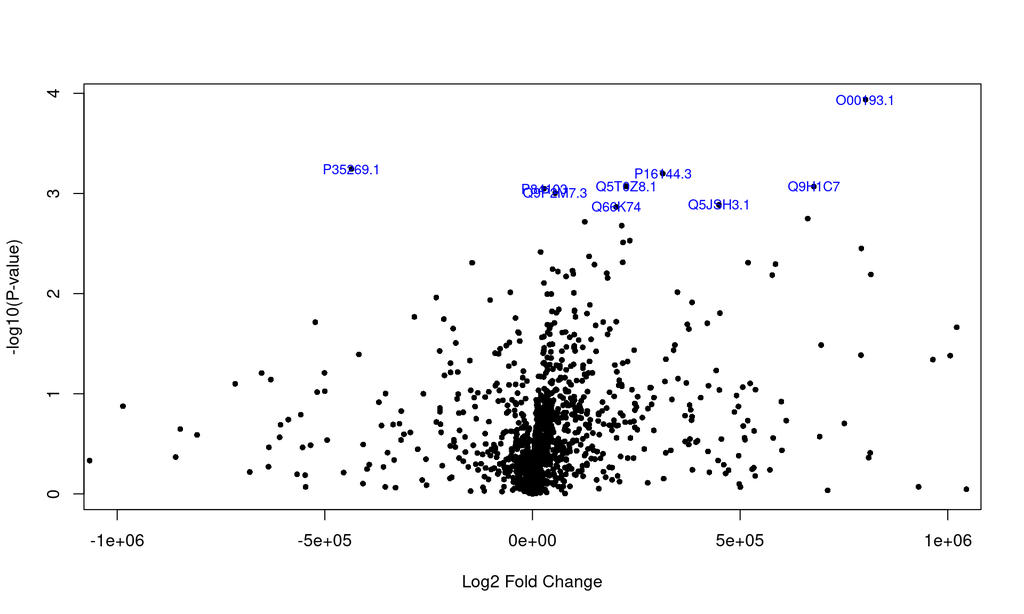

```r
volcanoplot(fit2, highlight=10, names=rownames(abundances), cex=0.75,
            xlim=c(-1e+06,1e+06))
```

The dispersion of the points suggests that the data are too variable so it may be good to review normalization and try to apply some type of dat scaling that reduces variability while keeping interesting differences.

# Obtaining and analyzing data from the web

## Overview of GEO

The NCBI Gene Expression Omnibus (GEO) serves as a public repository for a wide range of high-throughput experimental data. These data include single and dual channel microarray-based experiments measuring mRNA, genomic DNA, and protein abundance, as well as non-array techniques such as serial analysis of gene expression (SAGE), mass spectrometry proteomic data, and high-throughput sequencing data.

At the most basic level of organization of GEO, there are four basic entity types. The first three (Sample, Platform, and Series) are supplied by users; the fourth, the dataset, is compiled and curated by GEO staff from the user-submitted data. See the GEO home page for more information.

## Getting data from GEO

Getting data from GEO is really quite easy. There is only one command that is needed, `getGEO`.

This one function interprets its input to determine how to get the data from GEO and then parse the data into useful R data structures. Usage is quite simple.

To illustrate this we will use data from a study on Effect of the thermogenic gene program during adipocyte differentiation. The data for this study had been uploaded into the Gene Expression Omnibus (GEO). The dataset selected is identified with the accession number: GSE100924.

More information about the study can be found in GEO and in Gonzalo R. and Sanchez A."

```r
if (!require(GEOquery)) {
  BiocManager::install("GEOquery")
}
require(GEOquery)
gse <- getGEO("GSE100924")
class(gse)
```

```
## [1] "list"
```

```r
names(gse)
```

```
## [1] "GSE100924_series_matrix.txt.gz"
```

```r
gse[[1]]
```

```
## ExpressionSet (storageMode: lockedEnvironment)
## assayData: 41345 features, 12 samples
##   element names: exprs
## protocolData: none
## phenoData
##   sampleNames: GSM2696488 GSM2696489 ... GSM2696499 (12 total)
##   varLabels: title geo_accession ... tissue:ch1 (41 total)
##   varMetadata: labelDescription
## featureData
##   featureNames: 17200001 17200003 ... 17551169 (41345 total)
##   fvarLabels: ID probeset_id ... SPOT_ID (11 total)
##   fvarMetadata: Column Description labelDescription
## experimentData: use 'experimentData(object)'
##   pubMedIds: 28784777
## Annotation: GPL17400
```

```r
esetFromGEO <- gse[[1]]
```

The downloaded object is an `ExpressionSet` stored in a list. This means that instead of doing the painful process of creating the object step by step one can simply download it from GEO and start using it as in the previous section.

Notice that you can use the *extractor* methods `exprs`, `pdata` or `annotation` to extract information such as the expression matrix, the covariates and groups or the name of the annotations.

```r
head(exprs(esetFromGEO))
```

```
##          GSM2696488 GSM2696489 GSM2696490 GSM2696491 GSM2696492 GSM2696493 GSM2696494 GSM2696495
## 17200001    3.20029    3.50615    4.02275    3.76270    4.06865    3.52037    4.70548    5.24982
## 17200003    5.28563    3.96680    3.74980    3.07016    3.97049    4.61585    5.56200    5.34181
## 17200005    3.94606    3.86091    4.63312    4.54735    4.03701    4.08898    5.71954    5.29113
## 17200007    1.01048    3.66635    1.14634    0.88701    0.60752    1.60910    3.46499    1.75943
## 17200009    3.57565    4.70378    2.95695    2.42673    2.30139    1.75738    5.49507    3.06155
## 17200011    2.31764    1.57258    3.38455    3.35646    3.39126    3.46329    4.76046    4.47677
##          GSM2696496 GSM2696497 GSM2696498 GSM2696499
## 17200001    4.04017    3.46224    4.30360    2.98413
## 17200003    5.13661    3.98098    5.16437    4.10178
## 17200005    5.26329    4.48267    4.73535    5.51457
## 17200007    3.51163    1.40517    2.48746    1.76209
## 17200009    4.06403    5.68234    4.28133    4.02674
## 17200011    4.25648    3.88374    2.81876    4.64254
```

Before extracting the phenodata object it is good to look at which fields it contains.

```r
colnames(pData(esetFromGEO))
```

```
##  [1] "title"                   "geo_accession"           "status"
##  [4] "submission_date"         "last_update_date"        "type"
##  [7] "channel_count"           "source_name_ch1"         "organism_ch1"
## [10] "characteristics_ch1"     "characteristics_ch1.1"   "characteristics_ch1.2"
## [13] "characteristics_ch1.3"   "treatment_protocol_ch1"  "growth_protocol_ch1"
## [16] "molecule_ch1"            "extract_protocol_ch1"    "label_ch1"
## [19] "label_protocol_ch1"      "taxid_ch1"               "hyb_protocol"
## [22] "scan_protocol"           "description"             "data_processing"
## [25] "platform_id"             "contact_name"            "contact_email"
## [28] "contact_phone"           "contact_department"      "contact_institute"
## [31] "contact_address"         "contact_city"            "contact_state"
## [34] "contact_zip/postal_code" "contact_country"         "supplementary_file"
## [37] "data_row_count"          "cold exposure:ch1"       "gender:ch1"
## [40] "genotype:ch1"            "tissue:ch1"
```

Many of these columns contain repeated informations (a non-efficient way to store information about the study in the same table as the groups information).

The relevant information for the analysis seems to be in columns 38 to 41: “cold exposure:ch1”, “gender:ch1” , “genotype:ch1”, “tissue:ch1”.

```r
pData(esetFromGEO)[,c("cold exposure:ch1", "gender:ch1" , "genotype:ch1", "tissue:ch1")]
```

|  | cold exposure:ch1 | gender:ch1 | genotype:ch1 | tissue:ch1 |
| --- | --- | --- | --- | --- |
| GSM2696488 | Ambient room temperature | Male | wild type | Brown fat |
| GSM2696489 | Ambient room temperature | Male | wild type | Brown fat |
| GSM2696490 | Ambient room temperature | Male | wild type | Brown fat |
| GSM2696491 | Ambient room temperature | Male | Zbtb7b KO | Brown fat |
| GSM2696492 | Ambient room temperature | Male | Zbtb7b KO | Brown fat |
| GSM2696493 | Ambient room temperature | Male | Zbtb7b KO | Brown fat |
| GSM2696494 | Cold exposure | Male | wild type | Brown fat |
| GSM2696495 | Cold exposure | Male | wild type | Brown fat |
| GSM2696496 | Cold exposure | Male | wild type | Brown fat |
| GSM2696497 | Cold exposure | Male | Zbtb7b KO | Brown fat |

[output cut: 2 more lines]